# Identifying patient groups who might benefit from personalised dosing

#### 5.4. Dose vs. target values in patients stratified by race and sex

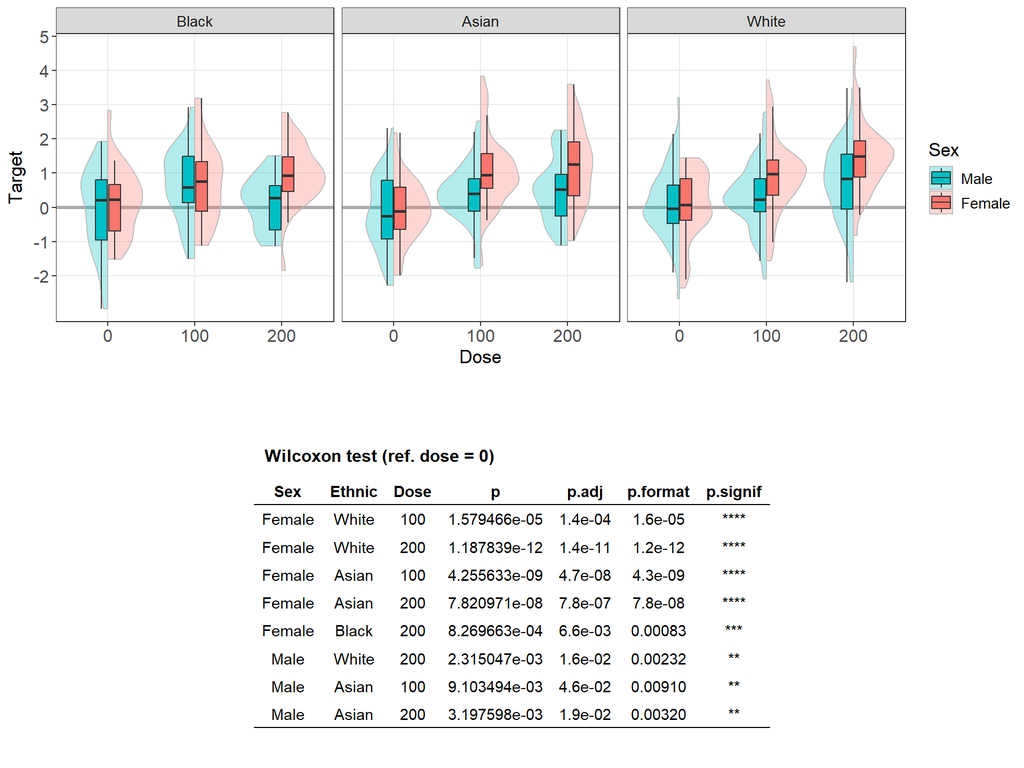

```r
# - Chunk_4d                                                 - #
# - Requires R-libraries and object exampleData (set-up)     - #
# - Requires object geom_split_violin (chunk: splitViolins)  - #

# Generate a table of significant differences (Wilcoxon test)

sign_test <- compare_means(
  data = exampleData,
  target ~ dose,
  group.by = c("sex", "race"),
  ref.group = "0",
  ) %>%
  filter (
    !group1 == "100" &
    !p.signif == "ns"  ) %>%
  select(!".y." & !"group1" & !"method")  %>%
  set_names(
    "Sex", "Ethnic", "Dose", "p", "p.adj", "p.format", "p.signif") %>%
  ggtexttable(
    rows = NULL,
    theme = ttheme("light")
    ) %>%
  tab_add_title(
    text = "Wilcoxon test (ref. dose = 0)",
    face = "bold", size = 12,
    )


# Generate split violin plot and insert the Wilcoxon test table

ggarrange(

exampleData %>%
  group_by(bmi, age, race, sex, type) %>%
  select (dose, target) %>%
  ggplot(
    aes(
      x= factor(dose, levels = c("0", "100", "200") ),
      y = target,
# Order low > high responders
    fill =
      factor(
        sex,
        levels = c("Male", "Female") )
        )
      ) +
# Color red for patient variable value with higher response
    scale_fill_hue( direction = -1) +
    geom_hline(
      yintercept = 0,
      color = "darkgrey",
      linewidth = 1.1
      ) +
    geom_split_violin(
      width = 1,
      alpha = 0.3,
      color = "grey") +
    geom_boxplot(
        width = 0.3,
        outlier.shape = NA) +
  # Order facets low > high responders
    facet_grid(.
      ~ factor(
        race,
        levels = c("Black", "Asian", "White")
        )
      ) +
    theme_bw() +
    theme(
      text=element_text( size = 13),
      axis.text = element_text( size = 12),
      ) +
    scale_y_continuous(
      breaks = c(-2: 5),
      minor_breaks = NULL
      ) +
    labs(
      x = "Dose",
      y = "Target",
      fill = "Sex",
      size = 12,
      hjust = -15
      ),

# Add space between plot and table
NULL,

sign_test,

ncol = 1, nrow = 3,
heights = c(2, 0.1, 2),
widths = c(0.2, 1, 1),
align = "h"
)
```

#### 5.5. Dose vs. target values in female patients stratified by ethnic and disease type

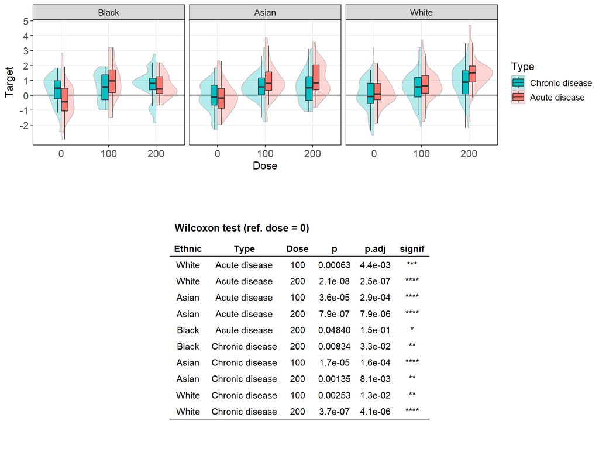

```r
# - Chunk_4e                                                 - #
# - Requires R-libraries and object exampleData (set-up)     - #
# - Requires object geom_split_violin (chunk: splitViolins)  - #

# Generate a table of significant differences (Wilcoxon test)

sign_test <-
  exampleData %>%
  filter(sex == "Female") %>%
  compare_means(
  data = .,
  target ~ dose,
  group.by = c("race", "type"),
  ref.group = "0",
  ) %>%
  filter (
    !group1 == "100" &
    !p.signif == "ns"  ) %>%
  select("race", "type", "group2", "p.format", "p.adj", "p.signif")  %>%
  set_names(
    "Ethnic", "Type", "Dose", "p", "p.adj", "signif") %>%
  ggtexttable(
    rows = NULL,
    theme = ttheme("light")
    ) %>%
  tab_add_title(
    text = "Wilcoxon test (ref. dose = 0)",
    face = "bold", size = 12,
    )


# Generate split violin plot and insert the Wilcoxon test table

ggarrange(

exampleData %>%
  group_by(bmi, age, race, sex, type) %>%
  select (dose, target) %>%
  ggplot(
    aes(
      x= factor(
        dose,
        levels = c("0", "100", "200")
        ),
         y = target,
# Order low > high responders
    fill = factor (type, levels = c("Chronic disease", "Acute disease") )
        )
      ) +
# Color red for patient variable value with higher response
    scale_fill_hue (direction = -1) +       geom_hline(
      yintercept = 0,
      color = "darkgrey",
      linewidth = 1.1
      ) +
    geom_split_violin(
      width = 1,
      alpha = 0.3,
      color = "grey") +
    geom_boxplot(
        width = 0.3,
        outlier.shape = NA) +
 # Order facets low > high responders
    facet_grid(.
      ~ factor(
        race,
        levels = c("Black", "Asian", "White")
        )
      ) +
    theme_bw() +
    theme(
      text=element_text( size = 13),
      axis.text = element_text( size = 12),
      ) +
    scale_y_continuous(
      breaks = c(-2: 5),
      minor_breaks = NULL
      ) +
    labs(
      x = "Dose",
      y = "Target",
      fill = "Type",
      size = 12,
      hjust = -15
      ),

# Add space between plot and table
NULL,

sign_test,

ncol = 1, nrow = 3,
heights = c(2, 0.1, 3),
widths = c(0.2, 1, 1),
align = "h"
)
```

#### 5.6. Dose vs. target values in female patients stratified by ethnic and age

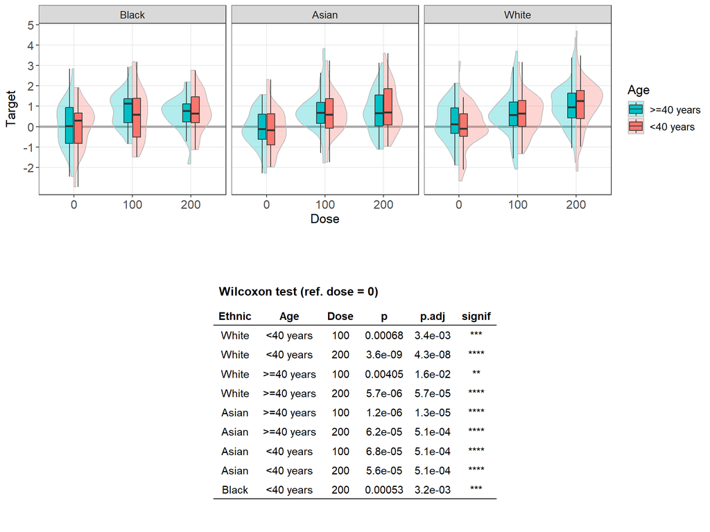

```r
# - Chunk_4f                                                 - #
# - Requires R-libraries and object exampleData (set-up)     - #
# - Requires object geom_split_violin (chunk: splitViolins)  - #

# Generate a table of significant differences (Wilcoxon test)

sign_test <-
  exampleData %>%
  filter(sex == "Female") %>%
  compare_means(
  data = .,
  target ~ dose,
  group.by = c("race", "age"),
  ref.group = "0",
  ) %>%
  filter (
    !group1 == "100" &
    !p.signif == "ns"  ) %>%
  select("race", "age", "group2", "p.format", "p.adj", "p.signif")  %>%
  set_names(
    "Ethnic", "Age", "Dose", "p", "p.adj", "signif") %>%
  ggtexttable(
    rows = NULL,
    theme = ttheme("light")
    ) %>%
  tab_add_title(
    text = "Wilcoxon test (ref. dose = 0)",
    face = "bold", size = 12,
    )


# Generate split violin plot and insert the Wilcoxon test table

ggarrange(

exampleData %>%
  group_by(bmi, age, race, sex, type) %>%
  select (dose, target) %>%
  ggplot (
    aes (x= factor(dose, levels = c("0", "100", "200") ),
         y = target,
# Order low > high responders
        fill = factor (age, levels = c(">=40 years", "<40 years") )
        )
      ) +
# Color red for patient variable value with higher response
    scale_fill_hue (direction = -1) +
    geom_hline(
      yintercept = 0,
      color = "darkgrey",
      linewidth = 1.1
      ) +
    geom_split_violin(
      width = 1,
      alpha = 0.3,
      color = "grey") +
    geom_boxplot(
        width = 0.3,
        outlier.shape = NA) +
 # Order facets low > high responders
    facet_grid(.
      ~ factor(
        race,
        levels = c("Black", "Asian", "White")
        )
      ) +
    theme_bw() +
    theme(
      text=element_text( size = 13),
      axis.text = element_text( size = 12),
      ) +
    scale_y_continuous(
      breaks = c(-2: 5),
      minor_breaks = NULL
      ) +
    labs(
      x = "Dose",
      y = "Target",
      fill = "Age",
      size = 12,
      hjust = -15
      ),

# Add space between plot and table
NULL,

sign_test,

ncol = 1, nrow = 3,
heights = c(2, 0.1, 2.5),
widths = c(0.2, 1, 1),
align = "h"
)
```

Younger white females appear to respond better than older, especially at the higher dose, whereas the opposite appears to be true for Asian females (not sure about the significance of that…).

#### 5.7. Dose vs. target values in White patients stratified by sex and disease type

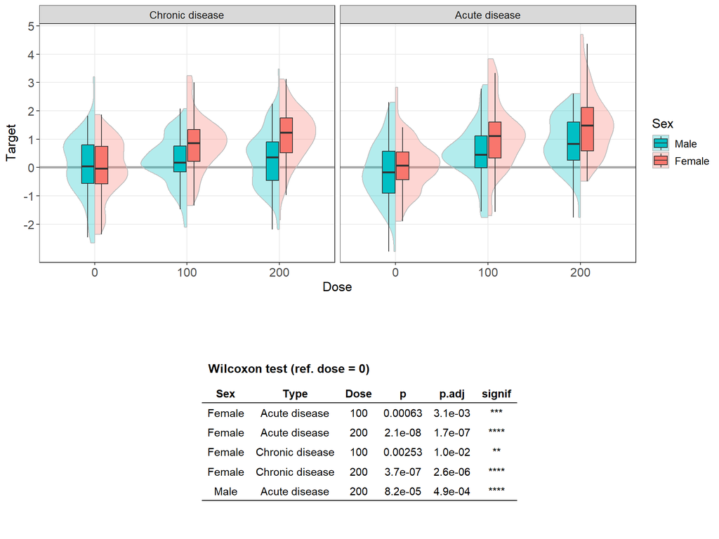

```r
# - Chunk_4g                                                 - #
# - Requires R-libraries and object exampleData (set-up)     - #
# - Requires object geom_split_violin (chunk: splitViolins)  - #

# Generate a table of significant differences (Wilcoxon test)

sign_test <-
  exampleData %>%
  filter(race == "White") %>%
  compare_means(
  data = .,
  target ~ dose,
  group.by = c("sex", "type"),
  ref.group = "0",
  ) %>%
  filter (
    !group1 == "100" &
    !p.signif == "ns"  ) %>%
  select("sex", "type", "group2", "p.format", "p.adj", "p.signif")  %>%
  set_names(
    "Sex", "Type", "Dose", "p", "p.adj", "signif") %>%
  ggtexttable(
    rows = NULL,
    theme = ttheme("light")
    ) %>%
  tab_add_title(
    text = "Wilcoxon test (ref. dose = 0)",
    face = "bold", size = 12,
    )


# Generate split violin plot and insert the Wilcoxon test table

ggarrange(

exampleData %>%
  group_by(bmi, age, race, sex, type) %>%
  select (dose, target) %>%
  ggplot (
    aes (x= factor(dose, levels = c("0", "100", "200") ),
         y = target,
# Order low > high responders
    fill =
      factor(
        sex,
        levels = c("Male", "Female") )
        )
      ) +
# Color red for patient variable value with higher response
    scale_fill_hue( direction = -1) +
    geom_hline(
      yintercept = 0,
      color = "darkgrey",
      linewidth = 1.1
      ) +
    geom_split_violin(
      width = 1,
      alpha = 0.3,
      color = "grey") +
    geom_boxplot(
        width = 0.3,
        outlier.shape = NA) +
 # Order facets low > high responders
    facet_grid(.
      ~ factor(
        type,
        levels = c("Chronic disease", "Acute disease")
        )
      ) +
    theme_bw() +
    theme(
      text=element_text( size = 13),
      axis.text = element_text( size = 12),
      ) +
    scale_y_continuous(
      breaks = c(-2: 5),
      minor_breaks = NULL
      ) +
    labs(
      x = "Dose",
      y = "Target",
      fill = "Sex",
      size = 12,
      hjust = -15
      ),

# Add space between plot and table
NULL,

sign_test,

ncol = 1, nrow = 3,
heights = c(2, 0.1, 1.5),
widths = c(0.2, 1, 1),
align = "h"
)
```

#### 5.8. Dose vs. target values in White patients stratified by sex and age

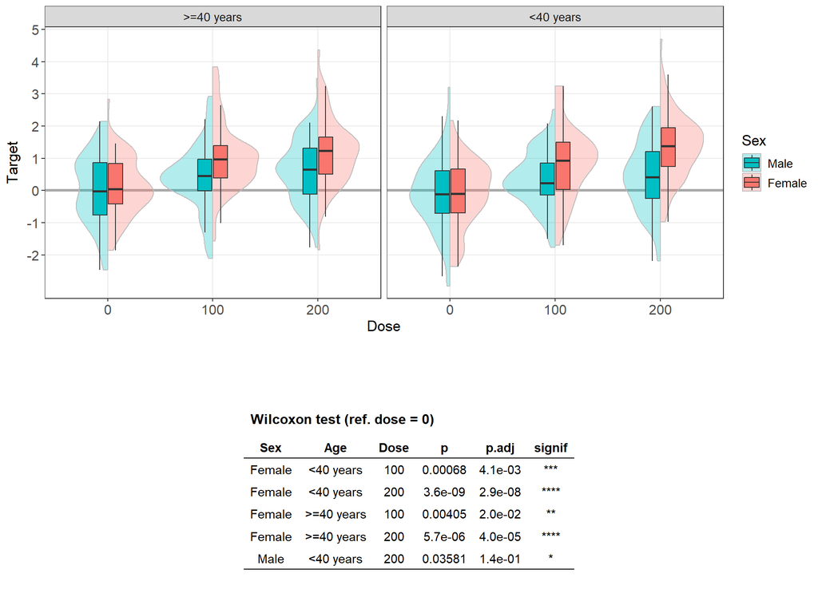

```r
# - Chunk_4h                                                 - #
# - Requires R-libraries and object exampleData (set-up)     - #
# - Requires object geom_split_violin (chunk: splitViolins)  - #

# Generate a table of significant differences (Wilcoxon test)

sign_test <-
  exampleData %>%
  filter(race == "White") %>%
  compare_means(
  data = .,
  target ~ dose,
  group.by = c("sex", "age"),
  ref.group = "0",
  ) %>%
  filter (
    !group1 == "100" &
    !p.signif == "ns"  ) %>%
  select("sex", "age", "group2", "p.format", "p.adj", "p.signif")  %>%
  set_names(
    "Sex", "Age", "Dose", "p", "p.adj", "signif") %>%
  ggtexttable(
    rows = NULL,
    theme = ttheme("light")
    ) %>%
  tab_add_title(
    text = "Wilcoxon test (ref. dose = 0)",
    face = "bold", size = 12,
    )


# Generate split violin plot and insert the Wilcoxon test table

ggarrange(

exampleData %>%
  group_by(bmi, age, race, sex, type) %>%
  select (dose, target) %>%
  ggplot(
    aes(
      x = factor(
        dose,
        levels = c("0", "100", "200")
        ),
      y = target,
# Order low > high responders
    fill =
      factor(
        sex,
        levels = c("Male", "Female") )
        )
      ) +
# Color red for patient variable value with higher response
    scale_fill_hue( direction = -1) +
    geom_hline(
      yintercept = 0,
      color = "darkgrey",
      linewidth = 1.1
      ) +
     geom_split_violin(
      width = 1,
      alpha = 0.3,
      color = "grey") +
    geom_boxplot(
        width = 0.3,
        outlier.shape = NA) +
# Order facets low > high responders
    facet_grid(.
      ~ factor(
        age,
        levels = c(">=40 years", "<40 years")
        )
      ) +
    theme_bw() +
    theme(
      text=element_text( size = 13),
      axis.text = element_text( size = 12),
      ) +
    scale_y_continuous(
      breaks = c(-2: 5),
      minor_breaks = NULL
      ) +
    labs(
      x = "Dose",
      y = "Target",
      fill = "Sex",
      size = 12,
      hjust = -15
      ),

# Add space between plot and table
NULL,

sign_test,

ncol = 1, nrow = 3,
heights = c(2, 0.1, 1.5),
widths = c(0.2, 1, 1),
align = "h"
)
```

#### 5.9. Dose vs. target values in patients stratified by race and BMI

(The difference between median targets in the Black/ low BMI/ dose 100 group had the highest significance in the Mood test)

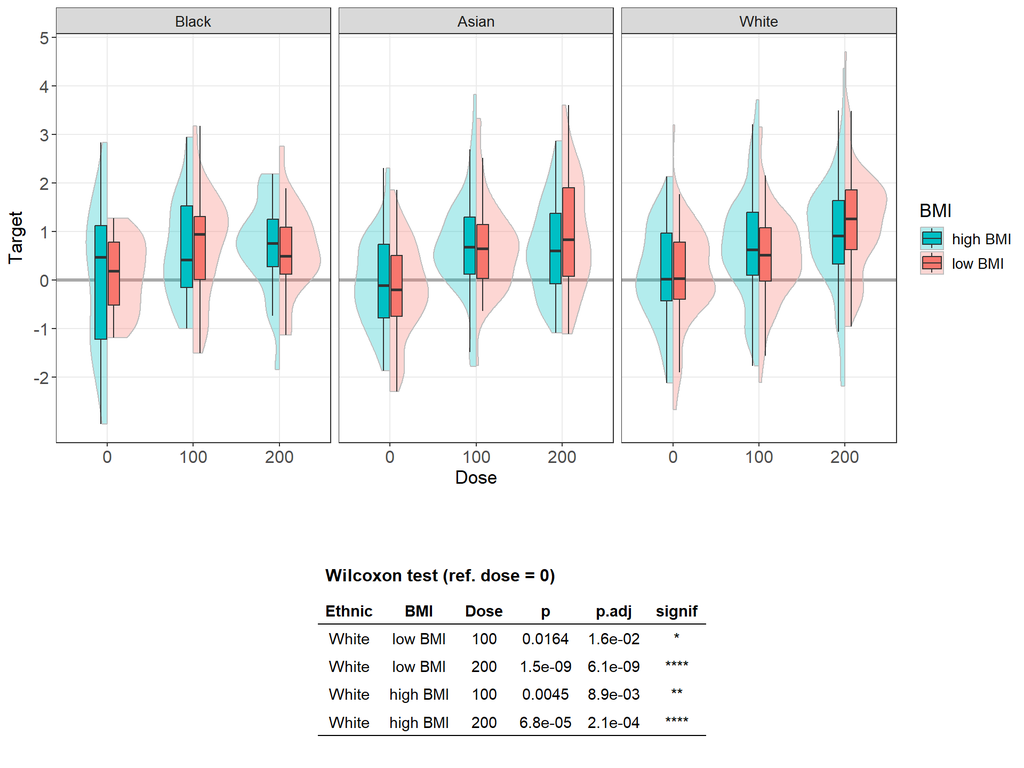

```r
# - Chunk_4i                                                 - #
# - Requires R-libraries and object exampleData (set-up)     - #
# - Requires object geom_split_violin (chunk: splitViolins)  - #

# Generate a table of significant differences (Wilcoxon test)

sign_test <-
  exampleData %>%
  filter(race == "White") %>%
  compare_means(
  data = .,
  target ~ dose,
  group.by = c("race", "bmi"),
  ref.group = "0",
  ) %>%
  filter (
    !group1 == "100" &
    !p.signif == "ns"  ) %>%
  select("race", "bmi", "group2", "p.format", "p.adj", "p.signif")  %>%
  set_names(
    "Ethnic", "BMI", "Dose", "p", "p.adj", "signif") %>%
  ggtexttable(
    rows = NULL,
    theme = ttheme("light")
    ) %>%
  tab_add_title(
    text = "Wilcoxon test (ref. dose = 0)",
    face = "bold", size = 12,
    )


# Generate split violin plot and insert the Wilcoxon test table

ggarrange(

exampleData %>%
  group_by(bmi, age, race, sex, type) %>%
  select(dose, target) %>%
  ggplot(
    aes(
      x= factor(
        dose,
        levels = c("0", "100", "200")
        ),
      y = target,
      fill = bmi
      )
    ) +
# Color red for patient variable value with higher response
    scale_fill_hue (direction = -1) +
    geom_hline(
      yintercept = 0,
      color = "darkgrey",
      linewidth = 1.1
      ) +
     geom_split_violin(
      width = 1,
      alpha = 0.3,
      color = "grey") +
    geom_boxplot(
        width = 0.3,
        outlier.shape = NA) +
  # Order facets low > high responders
    facet_grid(.
      ~ factor(
        race,
        levels = c("Black", "Asian", "White")
        )
      ) +
    theme_bw() +
    theme(
      text=element_text( size = 13),
      axis.text = element_text( size = 12),
      ) +
    scale_y_continuous(
      breaks = c(-2: 5),
      minor_breaks = NULL
      ) +
    labs(
      x = "Dose",
      y = "Target",
      fill = "BMI",
      size = 12,
      hjust = -15
      ),

# Add space between plot and table
NULL,

sign_test,

ncol = 1, nrow = 3,
heights = c(2, 0.1, 1),
widths = c(0.2, 1, 1),
align = "h"
)
```

### 6. Groups with the highest and lowest responses

#### 6.1. White females <40 years respond better than the remaining patients

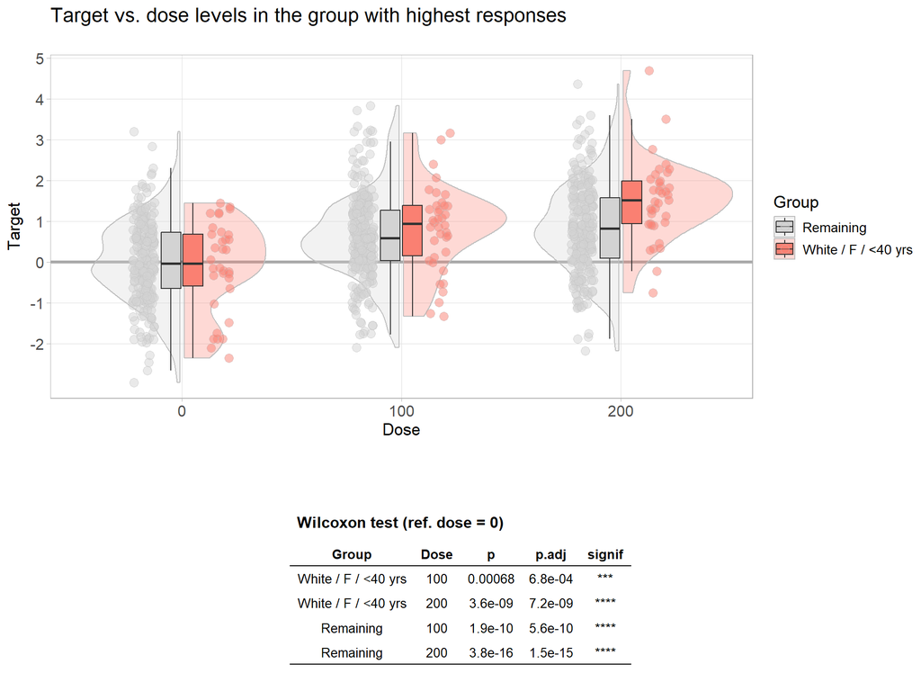

```r
# - Chunk_5a                                                 - #
# - Requires R-libraries and object exampleData (set-up)     - #
# - Requires object geom_split_violin (chunk: splitViolins)  - #

# Generate a table of significant differences (Wilcoxon test)

exampleData <-
  exampleData %>%
    mutate(
      Group =
        case_when(
          race == "White" &
          #type == "Acute disease" &
          age == "<40 years" &
          sex == "Female"
             ~ "White / F / <40 yrs",
        TRUE ~ "Remaining"
        )
      )

sign_test <-
  exampleData %>%
  compare_means(
  data = .,
  target ~ dose,
  group.by = "Group",
  ref.group = "0",
  ) %>%
  filter (
    !group1 == "100" &
    !p.signif == "ns"  ) %>%
  select("Group", "group2", "p.format", "p.adj", "p.signif")  %>%
  set_names(
    "Group", "Dose", "p", "p.adj", "signif") %>%
  ggtexttable(
    rows = NULL,
    theme = ttheme(
      "light",
      base_size = 10
      ),
    ) %>%
  tab_add_title(
    text = "Wilcoxon test (ref. dose = 0)",
    face = "bold", size = 12,
    )

# Generate split violin plot and insert the Wilcoxon test table

ggarrange(

exampleData %>%
  select (dose, target, type, Group) %>%
  group_by(Group) %>%
  ggplot(
    aes(
      x= factor(
        dose,
        levels = c("0", "100", "200")
        ),
      y = target,
      fill = Group
      )
    ) +
    geom_hline(
      yintercept = 0,
      color = "darkgrey",
      linewidth = 1.1
      ) +
    fill_palette(
      palette = c("lightgrey","salmon")
      ) +
    geom_split_violin(
      width = 1,
      nudge = 0.01,
      alpha = 0.3,
      color = "grey") +
    geom_boxplot(
      width = 0.2,
      outlier.shape = NA) +
    geom_point(
      pch = 21,
      size = 3,
      position =
        position_jitterdodge(
          dodge.width = 0.7,
          jitter.width = 0.1
          ),
      color = "grey",
      alpha = 0.5
      ) +
    theme_light() +
    theme(
      text=element_text( size = 13),
      axis.text = element_text( size = 12),
      ) +
    scale_y_continuous(
      breaks = c(-2: 5),
      minor_breaks = NULL
      ) +
    labs(
      x = "Dose",
      y = "Target",
      size = 13, hjust = -15,
      title = "Target vs. dose levels in the group with highest responses\n"
      ),

# Add space between plot and table
NULL,

sign_test,

ncol = 1, nrow = 3,
heights = c(2, 0.1, 1),
widths = c(0.2, 1, 1),
align = "h"
)
```

#### 6.2. Black males with chronic disease show no or negative response

However, this might need confirmation in a larger sample of this subgroup.

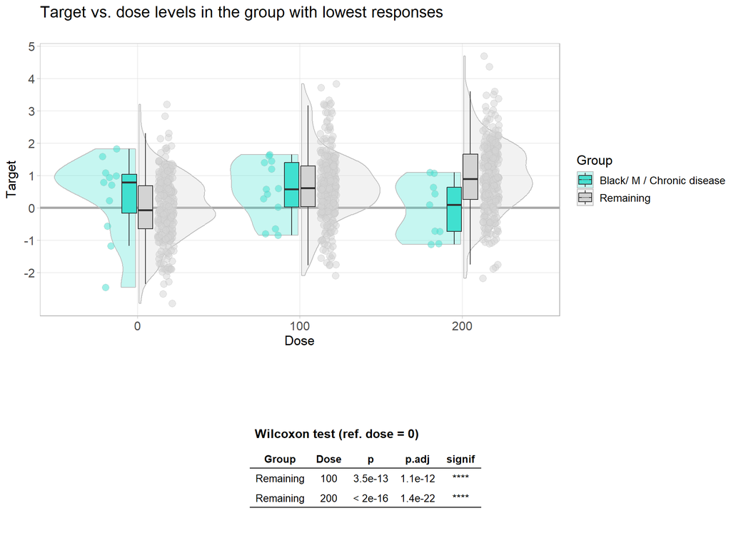

```r
# - Chunk_5b                                                 - #
# - Requires R-libraries and object exampleData (set-up)     - #
# - Requires object geom_split_violin (chunk: splitViolins)  - #

# Generate a table of significant differences (Wilcoxon test)

exampleData <-
  exampleData %>%
    mutate(
      Group =
        case_when(
          race == "Black" &
          # bmi == "high BMI" &
           type == "Chronic disease" &
          # age == ">=40 years" &
          sex == "Male"
             ~ "Black/ M / Chronic disease",
        TRUE ~ "Remaining"
        )
      )

sign_test <-
  exampleData %>%
  compare_means(
  data = .,
  target ~ dose,
  group.by = "Group",
  ref.group = "0",
  ) %>%
  filter (
    !group1 == "100" &
    !p.signif == "ns"  ) %>%
  select("Group", "group2", "p.format", "p.adj", "p.signif")  %>%
  set_names(
    "Group", "Dose", "p", "p.adj", "signif") %>%
  ggtexttable(
    rows = NULL,
    theme = ttheme(
      "light",
      base_size = 10
      ),
    ) %>%
  tab_add_title(
    text = "Wilcoxon test (ref. dose = 0)",
    face = "bold", size = 12,
    )

# Generate split violin plot and insert the Wilcoxon test table

ggarrange(

exampleData %>%
  select (dose, target, type, Group) %>%
  group_by(Group) %>%
  ggplot(
    aes(
      x= factor(
        dose,
        levels = c("0", "100", "200")
        ),
      y = target,
      fill = Group
      )
    ) +
    geom_hline(
      yintercept = 0,
      color = "darkgrey",
      linewidth = 1.1
      ) +
    fill_palette(
      palette = c("turquoise", "lightgrey")
      ) +
    geom_split_violin(
      width = 1,
      nudge = 0.01,
      alpha = 0.3,
      color = "grey") +
  geom_boxplot(
      width = 0.2,
      outlier.shape = NA) +
  geom_point(
    pch = 21,
    size = 3,
    position =
      position_jitterdodge(
        dodge.width = 0.7,
        jitter.width = 0.1
        ),
    color = "grey",
    alpha = 0.5
    ) +
  theme_light() +
  theme(
    text=element_text( size = 13),
    axis.text = element_text( size = 12),
    ) +
  scale_y_continuous(
    breaks = c(-2: 5),
    minor_breaks = NULL
    ) +    labs(
      x = "Dose",
      y = "Target",
      size = 13, hjust = -15,
      title = "Target vs. dose levels in the group with lowest responses\n"
      ),

# Add space between plot and table
NULL,

sign_test,

ncol = 1, nrow = 3,
heights = c(2, 0.1, 1),
widths = c(0.2, 1, 1),
align = "h"
)
```

### 7. Questions and advanced alternative visualisations

The distribution of target in the total population looks similar for all 3 doses, and suggests that at least two major subgroups exist that might respond differently.

*Forest/UpSet plot*

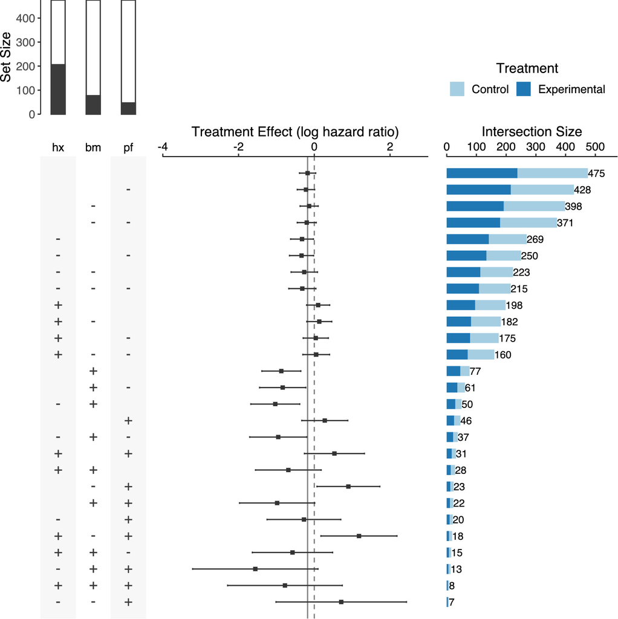

The webinar discussed anothor alternative, similar to the package “subscreen” (SAS® version 9.4 and R), and now available online as a shiny app<sup>3</sup>. “Subscreen” can handle huge data sets with millions of subgroups, and replace the usually lengthy and tedious explorative search for striking subgroups was replaced by an interactive, comprehensive, and coherent screening <sup>4</sup>. In accordance with the exploratory approach, p-values and confidence intervals are not calculated to leave room for interdisciplinary discussions of clinical relevance.

*Data exploration with Subscreen*

[figure not shown]

[figure not shown]

### 8. References

1. [A critical review of graphics for subgroup analyses in clinical trials](https://doi.org/10.1002/pst.2012). Ballarini NM, Chiu YD, König F, Posch M, Jaki T. Pharm Stat. 2020 Sep;19(5):541-560
2. SubgrPlots: Graphical Displays for Subgroup Analysis in Clinical Trials. R package version 0.1.0 Ballarini N, Chiu YD.; 2018
3. Dose Response In Subgroups (“DoRiS”, link not found)
4. [A novel concept of screening for subgrouping factors for the association between socioeconomic status and respiratory allergies](https://doi.org/10.1038/s41370-021-00365-x) Muysers, C., Messina, F., Keil, T. et al. J Expo Sci Environ Epidemiol 2022, 32: 295–302